# Vertnet

```python
from datascience import *
import json, urllib
import plotly.plotly as py
import plotly
import plotly.graph_objs as go
from plotly.offline import download_plotlyjs, init_notebook_mode, plot, iplot
import pandas as pd
import numpy as np
import calendar
import datetime
import matplotlib.pyplot as plt
%matplotlib inline
import pylab as pl
```

```python
import dash
import dash_core_components as dcc
import dash_html_components as html
```

```python
lizards=Table.read_table("lizards_large.txt")
```

```python
lizards
```

| type | modified | license | rightsholder | accessrights | bibliographiccitation | references | institutionid | collectionid | datasetid | institutioncode | collectioncode | datasetname | basisofrecord | informationwithheld | datageneralizations | dynamicproperties | occurrenceid | catalognumber | recordnumber | recordedby | individualcount | sex | lifestage | reproductivecondition | behavior | establishmentmeans | occurrencestatus | preparations | disposition | … |
| --- | --- | --- | --- | --- | --- | --- | --- | --- | --- | --- | --- | --- | --- | --- | --- | --- | --- | --- | --- | --- | --- | --- | --- | --- | --- | --- | --- | --- | --- | --- |
| PhysicalObject | 2017-09-27 13:48:00.0 | CC0 | nan | nan | California Academy of Sciences. CAS Herpetology (HERP). ... | http://portal.vertnet.org/o/cas/herp?id=urn-catalog-cas- ... | CAS | nan | nan | CAS | HERP | nan | PreservedSpecimen | nan | nan | nan | urn:catalog:CAS:HERP:176521 | 176521 | MRJ-419 | M.R. Jennings and M.P. Hayes | nan | female | Larva | nan | nan | nan | nan | Alcohol; Tissue: Heart (Frozen), Kidney (Frozen), Liver ... | nan | … |
| PhysicalObject | 2017-09-27 13:48:00.0 | CC0 | nan | nan | California Academy of Sciences. CAS Herpetology (HERP). ... | http://portal.vertnet.org/o/cas/herp?id=urn-catalog-cas- ... | CAS | nan | nan | CAS | HERP | nan | PreservedSpecimen | nan | nan | nan | urn:catalog:CAS:HERP:176531 | 176531 | MRJ-421 | M.R. Jennings and M.P. Hayes | nan | female | Adult | nan | nan | nan | nan | Alcohol; Tissue: Heart (Frozen), Kidney (Frozen), Liver ... | nan | … |
| PhysicalObject | 2017-09-27 13:48:00.0 | CC0 | nan | nan | California Academy of Sciences. CAS Herpetology (HERP). ... | http://portal.vertnet.org/o/cas/herp?id=urn-catalog-cas- ... | CAS | nan | nan | CAS | HERP | nan | PreservedSpecimen | nan | nan | nan | urn:catalog:CAS:HERP:176537 | 176537 | MRJ-427 | M.R. Jennings and M.P. Hayes | nan | male | Adult | nan | nan | nan | nan | Alcohol; Tissue: Heart (Frozen), Kidney (Frozen), Liver ... | nan | … |
| PhysicalObject | 2017-09-27 13:48:00.0 | CC0 | nan | nan | California Academy of Sciences. CAS Herpetology (HERP). ... | http://portal.vertnet.org/o/cas/herp?id=urn-catalog-cas- ... | CAS | nan | nan | CAS | HERP | nan | PreservedSpecimen | nan | nan | nan | urn:catalog:CAS:HERP:176538 | 176538 | MRJ-428 | M.R. Jennings and M.P. Hayes | nan | male | Adult | nan | nan | nan | nan | Alcohol; Tissue: Heart (Frozen), Kidney (Frozen), Liver ... | nan | … |
| PhysicalObject | 2017-09-27 13:48:00.0 | CC0 | nan | nan | California Academy of Sciences. CAS Herpetology (HERP). ... | http://portal.vertnet.org/o/cas/herp?id=urn-catalog-cas- ... | CAS | nan | nan | CAS | HERP | nan | PreservedSpecimen | nan | nan | nan | urn:catalog:CAS:HERP:176540 | 176540 | MRJ-430 | M.R. Jennings and M.P. Hayes | nan | male | Adult | nan | nan | nan | nan | Alcohol; Tissue: Heart (Frozen), Kidney (Frozen), Liver ... | nan | … |
| PhysicalObject | 2017-09-27 13:48:00.0 | CC0 | nan | nan | California Academy of Sciences. CAS Herpetology (HERP). ... | http://portal.vertnet.org/o/cas/herp?id=urn-catalog-cas- ... | CAS | nan | nan | CAS | HERP | nan | PreservedSpecimen | nan | nan | nan | urn:catalog:CAS:HERP:176541 | 176541 | MRJ-431 | M.R. Jennings and M.P. Hayes | nan | male | Adult | nan | nan | nan | nan | Alcohol; Tissue: Heart (Frozen), Kidney (Frozen), Liver ... | nan | … |
| PhysicalObject | 2017-09-27 13:48:00.0 | CC0 | nan | nan | California Academy of Sciences. CAS Herpetology (HERP). ... | http://portal.vertnet.org/o/cas/herp?id=urn-catalog-cas- ... | CAS | nan | nan | CAS | HERP | nan | PreservedSpecimen | nan | nan | nan | urn:catalog:CAS:HERP:176542 | 176542 | MRJ-432 | M.R. Jennings and M.P. Hayes | nan | male | Adult | nan | nan | nan | nan | Alcohol; Tissue: Heart (Frozen), Kidney (Frozen), Liver ... | nan | … |
| PhysicalObject | 2017-09-27 13:48:00.0 | CC0 | nan | nan | California Academy of Sciences. CAS Herpetology (HERP). ... | http://portal.vertnet.org/o/cas/herp?id=urn-catalog-cas- ... | CAS | nan | nan | CAS | HERP | nan | PreservedSpecimen | nan | nan | nan | urn:catalog:CAS:HERP:176549 | 176549 | MRJ-439 | M.R. Jennings and M.P. Hayes | nan | female | Adult | nan | nan | nan | nan | Alcohol; Tissue: Heart (Frozen), Kidney (Frozen), Liver ... | nan | … |
| PhysicalObject | 2017-09-27 13:48:00.0 | CC0 | nan | nan | California Academy of Sciences. CAS Herpetology (HERP). ... | http://portal.vertnet.org/o/cas/herp?id=urn-catalog-cas- ... | CAS | nan | nan | CAS | HERP | nan | PreservedSpecimen | nan | nan | nan | urn:catalog:CAS:HERP:176550 | 176550 | MRJ-440 | M.R. Jennings and M.P. Hayes | nan | male | Adult | nan | nan | nan | nan | Alcohol; Tissue: Heart (Frozen), Kidney (Frozen), Liver ... | nan | … |
| PhysicalObject | 2017-09-27 13:48:00.0 | CC0 | nan | nan | California Academy of Sciences. CAS Herpetology (HERP). ... | http://portal.vertnet.org/o/cas/herp?id=urn-catalog-cas- ... | CAS | nan | nan | CAS | HERP | nan | PreservedSpecimen | nan | nan | nan | urn:catalog:CAS:HERP:176557 | 176557 | MRJ-415 | M.R. Jennings and M.P. Hayes | nan | female | Adult | nan | nan | nan | nan | Alcohol; Tissue: Heart (Frozen), Kidney (Frozen), Liver ... | nan | … |

... (15990 rows omitted)

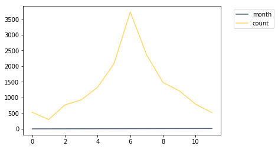

```python
lizards.select("month").group(0).plot()
```

More lizard samples are taken during the middle of the year. I am not sure if this is because more convenient for researchers or lizards are more common

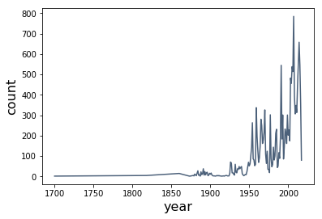

```python
lizards.select("year").group(0).plot(0,1)
```

Number of Samples per year plotted. It is difficult to determine if the change over time is from samples no longer being collected or lizards being less common

```python
lizards.select("sex").group(0)
```

| sex | count |
| --- | --- |
| [female] | 22 |
| [male?] | 1 |
| [male] | 24 |
| f? | 5 |
| female | 6688 |
| female ? | 7 |
| female ?; male | 1 |
| female; female | 159 |
| female; female ? | 5 |
| female; female; female; female; female; female | 3 |

... (18 rows omitted)

While trying to group the samples by sex, it seems the samples are not very accurate.

```python
lizards_map=lizards.select("decimallatitude", "decimallongitude", "locality").groups([0,1,2])
lizards_map
```

| decimallatitude | decimallongitude | locality | count |
| --- | --- | --- | --- |
| 8.01603 | -77.7168 | Darién National Park, Rancho Frio | 2 |
| 9.15786 | -79.8466 | Barro Colorado Island | 109 |
| 14.1369 | -85.7476 | Villa Nueva de Yamales | 2 |
| 14.8764 | -87.971 | Lago de Yojoa | 2 |
| 15.2333 | -92.2955 | 0.7 km S (by air) of Ejido Boqueron, Municipio Motozintla | 1 |
| 15.2372 | -92.3009 | Cerro Boqueron, 0.7 km WSW (by air) of Ejido Boqueron, M ... | 1 |
| 15.2393 | -92.3071 | Summit of Cerro Boqueron, 1.3 km W (by air) of Ejido Boq ... | 1 |
| 15.5827 | -87.9148 | 3.3 miles SE Choloma | 2 |
| 15.7425 | -87.4588 | Lancetilla Experimental Station | 1 |
| 16.7778 | -92.6814 | 4 mi NW San Cristóbal de las Casas | 2 |

... (6653 rows omitted)

```python
lizards_map
```

| decimallatitude | decimallongitude | locality | count |
| --- | --- | --- | --- |
| 8.01603 | -77.7168 | Darién National Park, Rancho Frio | 2 |
| 9.15786 | -79.8466 | Barro Colorado Island | 109 |
| 14.1369 | -85.7476 | Villa Nueva de Yamales | 2 |
| 14.8764 | -87.971 | Lago de Yojoa | 2 |
| 15.2333 | -92.2955 | 0.7 km S (by air) of Ejido Boqueron, Municipio Motozintla | 1 |
| 15.2372 | -92.3009 | Cerro Boqueron, 0.7 km WSW (by air) of Ejido Boqueron, M ... | 1 |
| 15.2393 | -92.3071 | Summit of Cerro Boqueron, 1.3 km W (by air) of Ejido Boq ... | 1 |
| 15.5827 | -87.9148 | 3.3 miles SE Choloma | 2 |
| 15.7425 | -87.4588 | Lancetilla Experimental Station | 1 |
| 16.7778 | -92.6814 | 4 mi NW San Cristóbal de las Casas | 2 |

... (6653 rows omitted)

```python
lizard_df_full = pd.DataFrame({'Latitude':lizards_map.select("decimallatitude").column(0),
                           "Longitude":lizards_map.select("decimallongitude").column(0),
                               "Locality":lizards_map.select("locality").column(0),
                         "Count":lizards_map.select("count").column(0)})
```

```python
lizard_df=lizard_df_full.take(range(6000))
lizard_df
```

|  | Latitude | Longitude | Locality | Count |
| --- | --- | --- | --- | --- |
| 0 | 8.016030 | -77.716830 | Darién National Park, Rancho Frio | 2 |
| 1 | 9.157860 | -79.846570 | Barro Colorado Island | 109 |
| 2 | 14.136850 | -85.747600 | Villa Nueva de Yamales | 2 |
| 3 | 14.876440 | -87.970960 | Lago de Yojoa | 2 |
| 4 | 15.233350 | -92.295540 | 0.7 km S (by air) of Ejido Boqueron, Municipio... | 1 |
| 5 | 15.237220 | -92.300870 | Cerro Boqueron, 0.7 km WSW (by air) of Ejido B... | 1 |
| 6 | 15.239330 | -92.307150 | Summit of Cerro Boqueron, 1.3 km W (by air) of... | 1 |
| 7 | 15.582730 | -87.914760 | 3.3 miles SE Choloma | 2 |
| 8 | 15.742527 | -87.458755 | Lancetilla Experimental Station | 1 |
| 9 | 16.777778 | -92.681389 | 4 mi NW San Cristóbal de las Casas | 2 |
| 10 | 16.907778 | -93.272222 | Berriozabal, 12 km N | 1 |
| 11 | 19.069444 | -97.360000 | 8 mi NE Chalchicomula [=Ciudad Serdán] | 2 |
| 12 | 19.425000 | -104.023060 | San Antonio | 1 |
| 13 | 19.557567 | -101.420468 | Cerro San Andres, 20 mi SSW Morelia | 1 |
| 14 | 19.701670 | -100.748736 | 30 mi E Morelia | 1 |
| 15 | 19.816110 | -101.790560 | Zacapú | 3 |
| 16 | 20.569386 | -98.775406 | 3km south-southeast of Matztitlan | 1 |
| 17 | 22.488772 | -99.423455 | 17 road km west of El Navajo | 1 |
| 18 | 23.254352 | -106.476311 | Isla de los Pajaros | 1 |
| 19 | 24.314203 | -100.296301 | Rancho El Mezcal, 9.6km E. of El Canelo | 1 |
| 20 | 24.742964 | -99.987684 | 8 mi SE Galeana | 1 |
| 21 | 24.837695 | -100.831055 | Canon de La Carbonera near Carbonera | 1 |
| 22 | 24.868333 | -100.231667 | Cerro El Potosí | 3 |
| 23 | 25.141791 | -80.925349 | Flamingo | 1 |
| 24 | 25.253400 | -107.258500 | San Acacia, ~20 miles W of I 25 exit | 1 |
| 25 | 25.258284 | -100.677248 | Rancho El Gavillero, 13km E. of San Antonio de... | 1 |
| 26 | 25.283950 | -80.321800 | Key Largo, County Road 905A, 0.5 mi E Steamboa... | 1 |
| 27 | 25.370005 | -100.161485 | 1 road km above (west +/-) Puerto Genovevo; ab... | 1 |
| 28 | 25.943167 | -81.729170 | Marco, back of beach 2 mi. S Marco | 1 |
| 29 | 26.168566 | -81.417503 | Big Cypress Swamp | 1 |
| ... | ... | ... | ... | ... |
| 5970 | 61.155930 | -152.867130 | SE shore of Lake Kenibuna | 1 |
| 5971 | 61.157767 | -152.851367 | 6.8 km SW of Chilligan Point | 1 |
| 5972 | 61.160000 | -138.580000 | Kluane Lake, 1073 mi Alaska Highway | 1 |
| 5973 | 61.166192 | -149.934239 | Anchorage, Ted Stevens Anchorage International... | 1 |
| 5974 | 61.166667 | -138.566667 | 1073 mi Alaska Hwy.,5.6 mi S,7.9 mi E of Destr... | 1 |
| 5975 | 61.166667 | -138.566667 | mi 1073 Alaska Hwy.,5.6 mi S,7.9 mi E of Destr... | 2 |
| 5976 | 61.183333 | -138.633333 | mi 1075 Alaska Hwy.,4.9 mi S,6.8 mi E of Destr... | 1 |
| 5977 | 61.199780 | -147.481290 | Meares Glacier, 38 miles west of Valdez, AK | 1 |
| 5978 | 61.200450 | -133.046933 | Canol Highway; Rose River Crossing #1 and High... | 5 |
| 5979 | 61.216667 | -149.883333 | Anchorage, Baxter Bog Park | 1 |
| 5980 | 61.226580 | -113.606300 | Fort Resolution | 17 |
| 5981 | 61.250000 | -165.616667 | mouth of Tutakoke River | 2 |
| 5982 | 61.316667 | -149.683333 | Eagle River along Pole Line Road | 1 |
| 5983 | 61.333333 | -150.616667 | no specific locality recorded | 1 |
| 5984 | 61.343889 | -148.860000 | 2 miles E of Bold Peak | 1 |
| 5985 | 61.354640 | -145.292680 | Copper River Basin; Tiekel Area; Milepost 53 R... | 1 |
| 5986 | 61.365000 | -148.908333 | 2 miles N of Bold Peak | 1 |
| 5987 | 61.368730 | -145.274100 | Copper River Basin; Tiekel area; Mile 54, Rich... | 1 |
| 5988 | 61.384010 | -145.234570 | Copper River Basin; Tiekel area; Mile 56, Rich... | 1 |
| 5989 | 61.388872 | -117.473210 | Northwest Territories Highway 3, km marker 42 | 1 |
| 5990 | 61.400833 | -150.508500 | bottom side of Bell Island on main channel of ... | 1 |
| 5991 | 61.402000 | -150.525333 | Big Susitna River, south Bell Island | 1 |
| 5992 | 61.404272 | -117.435210 | Northwest Territories Highway 3, km marker 42 ... | 1 |
| 5993 | 61.425687 | -117.404793 | Northwest Territories Highway 3, km marker 48 | 2 |
| 5994 | 61.426446 | -117.404667 | Northwest Territories Highway 3, km marker 48 | 1 |
| 5995 | 61.480820 | -145.152700 | Copper River Basin; Little Tonsina River; Mile... | 1 |
| 5996 | 61.490207 | -149.244780 | Glenn Highway, marsh at mile 29 | 1 |
| 5997 | 61.500000 | -165.000000 | Old Chevak (Dey-ook), Klavik River | 1 |
| 5998 | 61.516667 | -165.583333 | Ninglikfak River near Chevak | 2 |
| 5999 | 61.591980 | -145.228060 | Copper River Basin; Little Tonsina River; Mile... | 1 |

6000 rows × 4 columns

```python
import plotly.graph_objs as go
plotly.offline.init_notebook_mode(connected=True)

#lizard_df = lizard_df.sample(frac=0.1, replace=True)
cases = []
colors = ['rgb(239,243,255)','rgb(189,215,231)','rgb(107,174,214)','rgb(33,113,181)',
         'rgb(165,0,38)', 'rgb(215,48,39)', 'rgb(244,109,67)', 'rgb(253,174,97)',
         'rgb(254,224,144)', 'rgb(224,243,248)', 'rgb(171,217,233)', 'rgb(116,173,209)']
months = {1:"January", 2:"February", 3:"March", 4:"April",
          5:"May", 6:'June', 7:'July', 8:'Aug', 9:'Sept',
          10:"October", 11:"November", 12:"December"}

for i in range(1,13)[::-1]:
    cases.append(go.Scattergeo(
        lon = lizard_df['Longitude'],
        lat = lizard_df['Latitude'],
        marker = dict(
            size = lizard_df['Count'],
            color = colors[i-1],
            opacity = .4,
            line = dict(width = 0)
        ),
    ) )

cases[0]['mode'] = 'markers'

layout = go.Layout(
    title = 'Lizards Map',
    geo = dict(
        resolution = 110,
        scope = 'world',
        showframe = False,
        showcoastlines = True,
        showland = True,
        landcolor = "rgb(40, 40, 40)",
        countrycolor = "rgb(255, 255, 255)" ,
        coastlinecolor = "rgb(255, 255, 255)",
        projection = dict(
            type = 'mercator'
        ),
        lonaxis = dict( range= [ -124.0, -113.0 ] ),
        lataxis = dict( range= [ 32.0, 43.0 ] ),

    ),
    legend = dict(
           traceorder = 'reversed'
    )
)


fig = go.Figure(layout=layout, data=cases)
#app.layout  = html.Div([
#    dcc.Graph(id='graph', figure=fig)])

#py.iplot(fig, filename='Vernet_map')
```

```python
import plotly.graph_objs as go
plotly.offline.init_notebook_mode(connected=True)

#lizard_df = lizard_df.sample(frac=0.1, replace=True)
cases = []
colors = ['rgb(239,243,255)','rgb(189,215,231)','rgb(107,174,214)','rgb(33,113,181)',
         'rgb(165,0,38)', 'rgb(215,48,39)', 'rgb(244,109,67)', 'rgb(253,174,97)',
         'rgb(254,224,144)', 'rgb(224,243,248)', 'rgb(171,217,233)', 'rgb(116,173,209)']
months = {1:"January", 2:"February", 3:"March", 4:"April",
          5:"May", 6:'June', 7:'July', 8:'Aug', 9:'Sept',
          10:"October", 11:"November", 12:"December"}


cases.append(go.Scattergeo(
    lon = lizard_df['Longitude'],
    lat = lizard_df['Latitude'],
    marker = dict(
        size = lizard_df['Count'],
        color = colors[i-1],
        opacity = .4,
        line = dict(width = 0)
        ),
    ) )

cases[0]['mode'] = 'markers'

layout = go.Layout(
    title = 'Lizards Map',
    geo = dict(
        resolution = 50,
        scope = 'world',
        showframe = False,
        showcoastlines = True,
        showland = True,
        landcolor = "rgb(40, 40, 40)",
        countrycolor = "rgb(255, 255, 255)" ,
        coastlinecolor = "rgb(255, 255, 255)",
        projection = dict(
            type = 'mercator'
        ),
        lonaxis = dict( range= [ -160.0, -90.0 ] ),
        lataxis = dict( range= [ -11.0, 30 ] ),

    ),
    legend = dict(
           traceorder = 'reversed'
    )
)


fig = go.Figure(layout=layout, data=cases)
#app.layout  = html.Div([
#    dcc.Graph(id='graph', figure=fig)])

py.iplot(fig, filename='Vernet_map')
```

[interactive chart not shown]

```python
import plotly.graph_objs as go
plotly.offline.init_notebook_mode()

#lizard_df = lizard_df.sample(frac=0.1, replace=True)
cases = []
colors = ['rgb(239,243,255)','rgb(189,215,231)','rgb(107,174,214)','rgb(33,113,181)',
         'rgb(165,0,38)', 'rgb(215,48,39)', 'rgb(244,109,67)', 'rgb(253,174,97)',
         'rgb(254,224,144)', 'rgb(224,243,248)', 'rgb(171,217,233)', 'rgb(116,173,209)']
months = {1:"January", 2:"February", 3:"March", 4:"April",
          5:"May", 6:'June', 7:'July', 8:'Aug', 9:'Sept',
          10:"October", 11:"November", 12:"December"}

for i in range(100):
    cases.append(go.Scattergeo(
        lon = [lizard_df['Longitude'][i]],
        lat = [lizard_df['Latitude'][i]],
        marker = dict(
            size = lizard_df['Count'][i],
            color = colors[1],
            opacity = .4,
            line = dict(width = 0)
        ),
    ) )

cases[0]['mode'] = 'markers'

layout = go.Layout(
    title = 'Hey look! It\'s a scatter plot on a map!',
    geo = dict(
        resolution = 110,
        scope = 'usa',
        showframe = False,
        showcoastlines = True,
        showland = True,
        landcolor = "rgb(229, 229, 229)",
        countrycolor = "rgb(255, 255, 255)" ,
        coastlinecolor = "rgb(255, 255, 255)",
        projection = dict(
            type = 'mercator'
        ),
        lonaxis = dict( range= [ -124.0, -113.0 ] ),
        lataxis = dict( range= [ 32.0, 43.0 ] ),

    ),
    legend = dict(
           traceorder = 'reversed'
    )
)


fig = go.Figure(layout=layout, data=cases)
plotly.offline.iplot(fig, validate=False, filename='iantest')
```

[interactive chart not shown]

```python
colors = ["rgb(0,116,217)","rgb(255,65,54)","rgb(133,20,75)"]
locations = []
scale = 10

for i in range(3):
    row=lizard_df.iloc[i:i+1]
    city = dict(
        type = 'scattergeo',
        locationmode = 'USA-states',
        lon = row['Longitude'],
        lat = row['Latitude'],
        text = row['Locality'],
        marker = dict(
            size = row["Count"],
            color = colors[i],
            line = dict(width=0.5, color='rgb(40,40,40)'),
            sizemode = 'diameter'),
        name='{0}'.format(row['Locality']))
    locations.append(city)
```

```python
row["Count"]
```

```
2    2
Name: Count, dtype: int64
```

```python
layout = dict(
        title = '2014 US city populations<br>(Click legend to toggle traces)',
        showlegend = True,
        geo = dict(
            scope='world',
            projection=dict( type='Mercator' ),
            showland = True,
            landcolor = 'rgb(217, 217, 217)',
            subunitwidth=1,
            countrywidth=1,
            subunitcolor="rgb(255, 255, 255)",
            countrycolor="rgb(255, 255, 255)"
        ),
    )
```

```python
fig = dict(data=locations, layout=layout)
py.iplot(fig, validate=False, filename='d3-bubble-map-populations')
```

[interactive chart not shown]

The idea behind this graph is to figure out a way to visualize the number of samples at each point. The area is supposed to correspond to the number of samples at the point but the Barro Colorado site has an abnormally large amount of items so it overshadows the other points. I am looking to maybe scale the points to see if it easiier to visualize. The gray bubble map above is similar to what I have in mind but I need to adjust the coloring

```python
scl = [0,"rgb(150,0,90)"],[.125,"rgb(0, 0, 200)"],[.25,"rgb(0, 25, 255)"], [.375,"rgb(0, 152, 255)"],[.5,"rgb(44, 255, 150)"],[.625,"rgb(151, 255, 0)"], [.75,"rgb(255, 234, 0)"],[.875,"rgb(255, 111, 0)"], [1,"rgb(255, 0, 0)"]

data = [ dict(
    lat = lizard_df['Latitude'],
    lon = lizard_df['Longitude'],
    text = lizard_df['Count'],
    marker = dict(
        #color = lizard_df['Count'],
        colorscale = scl,
        reversescale = True,
        opacity = 0.7,
        size = 2,
        colorbar = dict(
            thickness = 10,
            titleside = "right",
            outlinecolor = "rgba(68, 68, 68, 0)",
            ticks = "outside",
            ticklen = 3,
            dtick = 1
        ),
    ),
    type = 'scattergeo'
) ]
```

```python
layout = dict(
    geo = dict(
        scope = 'world',
        showland = True,
        landcolor = "rgb(212, 212, 212)",
        subunitcolor = "rgb(255, 255, 255)",
        countrycolor = "rgb(255, 255, 255)",
        showlakes = True,
        lakecolor = "rgb(255, 255, 255)",
        showsubunits = True,
        showcountries = True,
        resolution = 50,
        projection = dict(
            type = 'mercator',
            rotation = dict(
                lon = -100
            )
        ),
        lonaxis = dict(
            showgrid = True,
            gridwidth = 0.5,
            range= [ -140.0, -55.0 ],
            dtick = 5
        ),
        lataxis = dict (
            showgrid = True,
            gridwidth = 0.5,
            range= [ 20.0, 60.0 ],
            dtick = 5
        )
    ),
    title = 'Lizards',
)
```

```python
fig = { 'data':data, 'layout':layout }
py.iplot(fig, filename='Lizards')
```

[interactive chart not shown]

The colors do not seem to properly correspond to the count at each point

```python
np.mean(lizard_df['Count'])
```

```
3.63
```

```python
steps = []
for i in range(len(data)):
    step = dict(
        method = 'restyle',
        args = ['visible', [False] * len(data)],
    )
    step['args'][1][i] = True # Toggle i'th trace to "visible"
    steps.append(step)

sliders = [dict(
    active = 10,
    currentvalue = {"prefix": "Frequency: "},
    pad = {"t": 50},
    steps = steps
)]

layout = dict(sliders=sliders)

fig = dict(data=data, layout=layout)

py.iplot(fig, filename='Sine Wave Slider')
```

[output not shown]

```python
lizard_elevation=lizards.select("minimumelevationinmeters", "verbatimelevation", "minimumdepthinmeters",
               "maximumdepthinmeters", "verbatimdepth", "minimumdistanceabovesurfaceinmeters",
               "maximumdistanceabovesurfaceinmeters")
```

```python
lizard_elevation
```

| minimumelevationinmeters | verbatimelevation | minimumdepthinmeters | maximumdepthinmeters | verbatimdepth | minimumdistanceabovesurfaceinmeters | maximumdistanceabovesurfaceinmeters |
| --- | --- | --- | --- | --- | --- | --- |
| 1786.13 | ca 5860 ft | nan | nan | nan | nan | nan |
| 1786.13 | 5860 ft | nan | nan | nan | nan | nan |
| 1786.13 | 5860 ft | nan | nan | nan | nan | nan |
| 1786.13 | 5860 ft | nan | nan | nan | nan | nan |
| 1786.13 | 5860 ft | nan | nan | nan | nan | nan |
| 1786.13 | 5860 ft | nan | nan | nan | nan | nan |
| 1786.13 | 5860 ft | nan | nan | nan | nan | nan |
| 1786.13 | 5860 ft | nan | nan | nan | nan | nan |
| 1786.13 | 5860 ft | nan | nan | nan | nan | nan |
| nan | nan | nan | nan | nan | nan | nan |

... (15990 rows omitted)

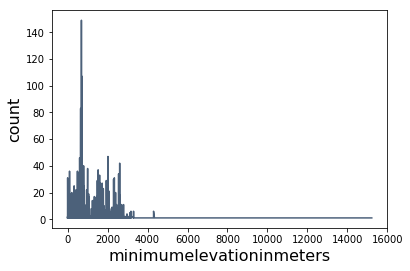

```python
lizard_elevation.select(0).group(0).plot(0,1)
```

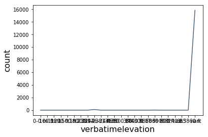

```python
lizard_elevation.select(1).group(0).plot(0,1)
```

```python
def log_progress(sequence, every=None, size=None, name='Items'):
    from ipywidgets import IntProgress, HTML, VBox
    from IPython.display import display

    is_iterator = False
    if size is None:
        try:
            size = len(sequence)
        except TypeError:
            is_iterator = True
    if size is not None:
        if every is None:
            if size <= 200:
                every = 1
            else:
                every = int(size / 200)     # every 0.5%
    else:
        assert every is not None, 'sequence is iterator, set every'

    if is_iterator:
        progress = IntProgress(min=0, max=1, value=1)
        progress.bar_style = 'info'
    else:
        progress = IntProgress(min=0, max=size, value=0)
    label = HTML()
    box = VBox(children=[label, progress])
    display(box)

    index = 0
    try:
        for index, record in enumerate(sequence, 1):
            if index == 1 or index % every == 0:
                if is_iterator:
                    label.value = '{name}: {index} / ?'.format(
                        name=name,
                        index=index
                    )
                else:
                    progress.value = index
                    label.value = u'{name}: {index} / {size}'.format(
                        name=name,
                        index=index,
                        size=size
                    )
            yield record
    except:
        progress.bar_style = 'danger'
        raise
    else:
        progress.bar_style = 'success'
        progress.value = index
        label.value = "{name}: {index}".format(
            name=name,
            index=str(index or '?')
        )
```

```python
lizards.select("modified").group(0)
```

| modified | count |
| --- | --- |
| 2005-04-27 03:37:09.0 | 1 |
| 2007-09-09 11:40:04.0 | 1 |
| 2007-10-12T18:49:23Z | 1 |
| 2007-10-12T18:54:03Z | 1 |
| 2007-11-06 12:19:26.0 | 1 |
| 2007-11-06 12:41:50.0 | 1 |
| 2007-11-15 11:58:48.0 | 1 |
| 2007-12-14 15:29:19.0 | 1 |
| 2008-11-11 10:02:43.0 | 1 |
| 2009-05-18 12:04:40.0 | 1 |

... (3876 rows omitted)

```python
lizard_dates=pd.DataFrame({'Dates':lizards.select("modified").group(0).column(0),
                           "Count":lizards.select("modified").group(0).column(1)})
```

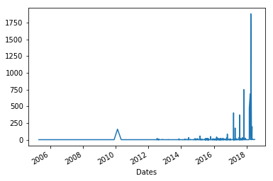

```python
lizard_dates.Dates=pd.to_datetime(lizard_dates.Dates)
lizard_dates=lizard_dates.set_index('Dates')
lizard_dates['Count'].plot()
```